# team.Rmd

**How are the ratings distributed? Create both a histogram and a boxplot and describe them. Don’t forget to mention outliers, if there are any.**

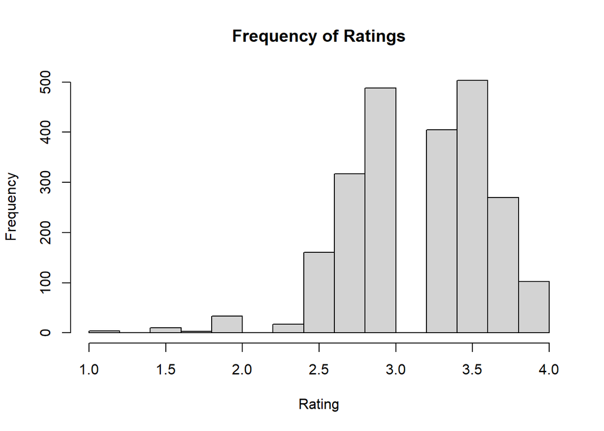

```r
 hist(choco$Rating, xlab = 'Rating', main = 'Frequency of Ratings')
```

This histogram is bimodal and left skewed. There are outliers on the left side. The most common ratings are around 2.75 and 3.5.

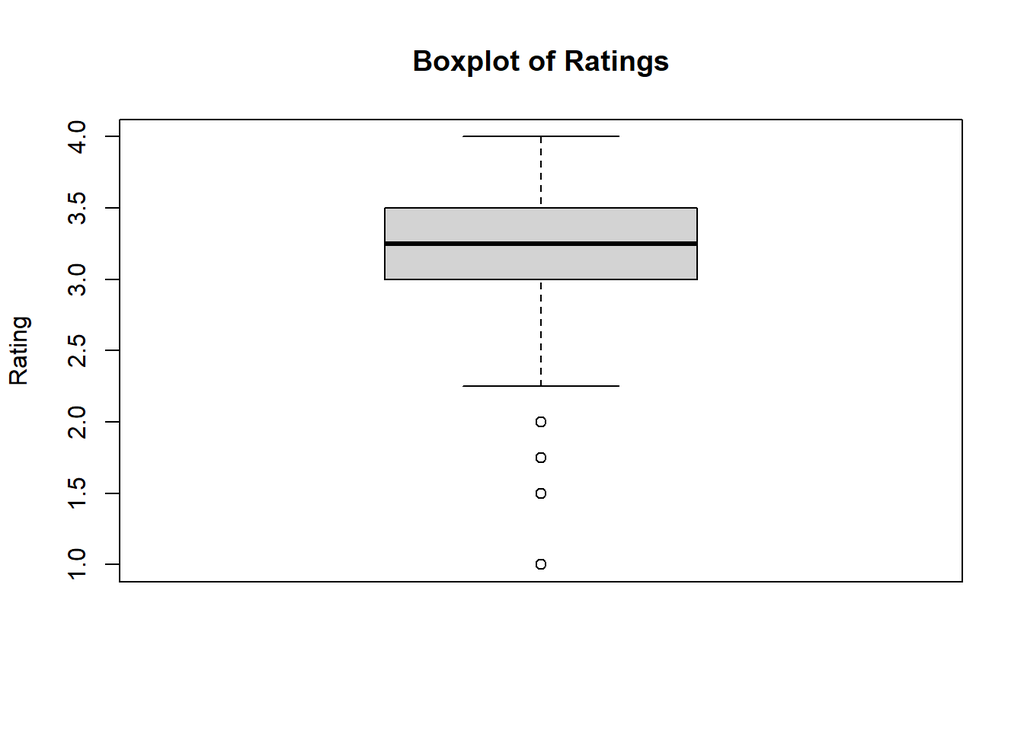

```r
boxplot(choco$Rating, ylab = 'Rating', main = 'Boxplot of Ratings')
```

This boxplot shows a small variance in the data.There are outliers in the lower values.

**How does the number of ratings depend on the location of the company? Draw a bar chart of the number of reports.**

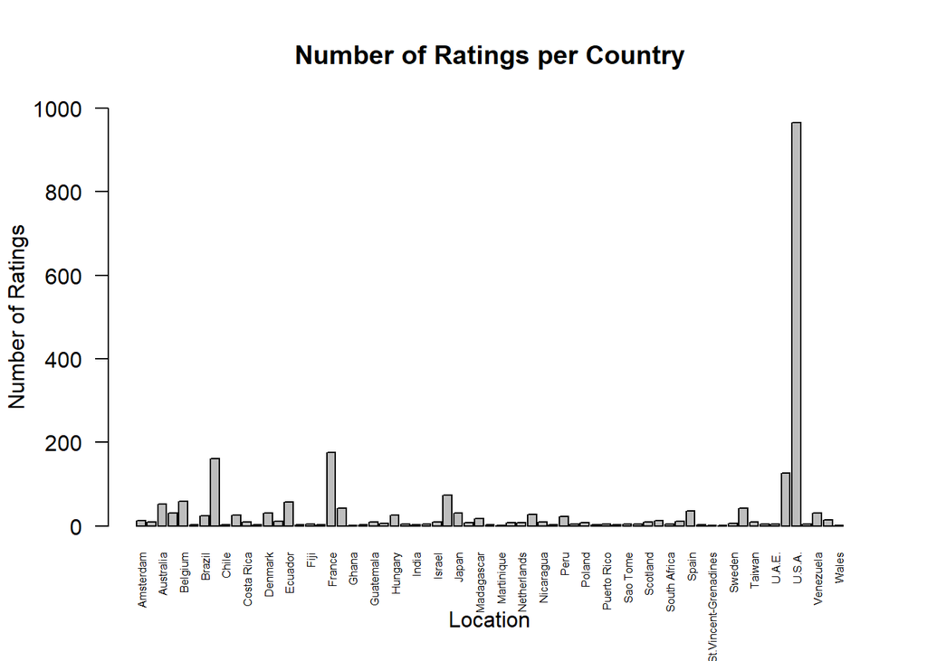

```r
barplot(table(choco$Location), xlab='Location', ylab='Number of Ratings', main='Number of Ratings per Country', cex.names=.5, las=2, ylim=c(0,1000))
```

**Do ratings depend on the cacao percentage of a chocolate bar? Create both numerical and graphical summaries, and explain. [Hint: Think about why the scatterplot is not a very good choice for visualization here.]**

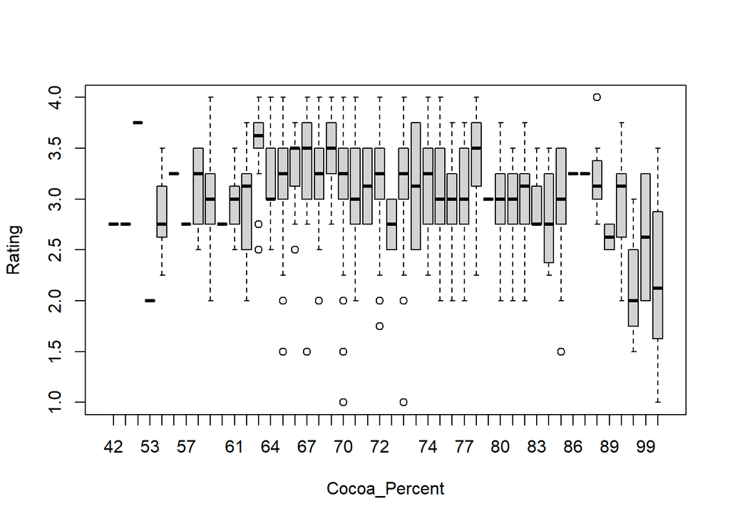

```r
boxplot(Rating ~ Cocoa_Percent, data = choco)
```

```r
table(choco$Rating, choco$Cocoa_Percent)
```

```
##
##         42  46  50  53  55  56  57  58  60 60.5  61  62  63  64  65  66  67  68
##   1      0   0   0   0   0   0   0   0   0    0   0   0   0   0   0   0   0   0
##   1.5    0   0   0   0   0   0   0   0   0    0   0   0   0   0   1   0   1   0
##   1.75   0   0   0   0   0   0   0   0   0    0   0   0   0   0   0   0   0   0
##   2      0   0   0   1   0   0   0   0   1    0   0   2   0   0   1   0   0   1
##   2.25   0   0   0   0   1   0   0   0   0    0   0   0   0   0   1   0   0   0
##   2.5    0   0   0   0   3   0   0   2   5    0   2   2   1   2   7   1   0   1
##   2.6    0   0   0   0   0   0   0   0   0    0   0   0   0   0   0   0   0   0
##   2.75   1   1   0   0   6   0   1   0   8    1   0   1   1   5   9   1   5   9
##   3      0   0   0   0   2   0   0   1  17    0   3   2   0  12  15   5   5  11
##   3.25   0   0   0   0   2   2   0   2  10    0   1   4   1   4  20   4   2  10
##   3.5    0   0   0   0   2   0   0   3   3    0   1   2   4   6  27  10   5  16
##   3.75   0   0   1   0   0   0   0   0   1    0   0   1   4   2   7   6  10  11
##   4      0   0   0   0   0   0   0   0   1    0   0   0   3   3   1   0   2   2
##
##         69  70  71 71.5  72 72.5  73 73.5  74  75  76  77  78  79  80  81  82
##   1      0   2   0    0   0    0   1    0   0   0   0   0   0   0   0   0   0
##   1.5    0   2   0    0   0    0   0    0   0   0   0   0   0   0   0   0   0
##   1.75   0   0   0    0   1    0   0    0   0   0   0   0   0   0   0   0   0
##   2      0   3   1    0   2    0   2    0   0   7   1   1   0   0   1   1   1
##   2.25   0   5   0    0   3    0   1    0   1   1   1   0   1   0   0   0   0
##   2.5    0  51   7    0  15    2   5    1   3  24   4   2   1   0   7   0   2
##   2.6    0   1   0    0   0    0   0    0   0   0   0   0   0   0   0   0   0
##   2.75   1 109   5    1  31    0   4    0  12  44   6  11   1   0  21   2   3
##   3      1 185  11    0  67    2   7    0  12  70   9   7   2   1  19   0   3
##   3.25   2 170   5    0  47    0  12    0   9  51   4   7   1   0  16   2   5
##   3.5    4 233  10    1  47    0  19    0  13  42   6   8   7   0  14   1   3
##   3.75   2 122   2    0  34    0   7    1   8  33   2   2   6   0   6   0   1
##   4      2  53   1    0  12    0   1    0   4  15   0   0   1   0   0   0   0
##
##         83  84  85  86  87  88  89  90  91  99 100
##   1      0   0   0   0   0   0   0   0   0   0   1
##   1.5    0   0   1   0   0   0   0   0   1   0   4
##   1.75   0   0   0   0   0   0   0   0   0   0   2
##   2      0   0   1   0   0   0   0   1   1   1   3
##   2.25   0   1   0   0   0   0   0   0   0   0   1
##   2.5    0   1   5   0   0   0   1   1   0   0   1
##   2.6    0   0   0   0   0   0   0   0   0   0   0
##   2.75   3   0   8   0   0   1   1   1   0   0   3
##   3      0   1   9   0   0   3   0   1   1   0   4
##   3.25   0   0   4   1   1   2   0   3   0   1   0
##   3.5    1   1  12   0   0   1   0   0   0   0   1
##   3.75   0   0   0   0   0   0   0   1   0   0   0
##   4      0   0   0   0   0   1   0   0   0   0   0
```

The cocoa percent does not largely affect the rating.

**How do different bean origins compare in terms of the flavor of chocolates? Are beans from some places better than the other? Create both numerical and graphical summaries, and explain.**

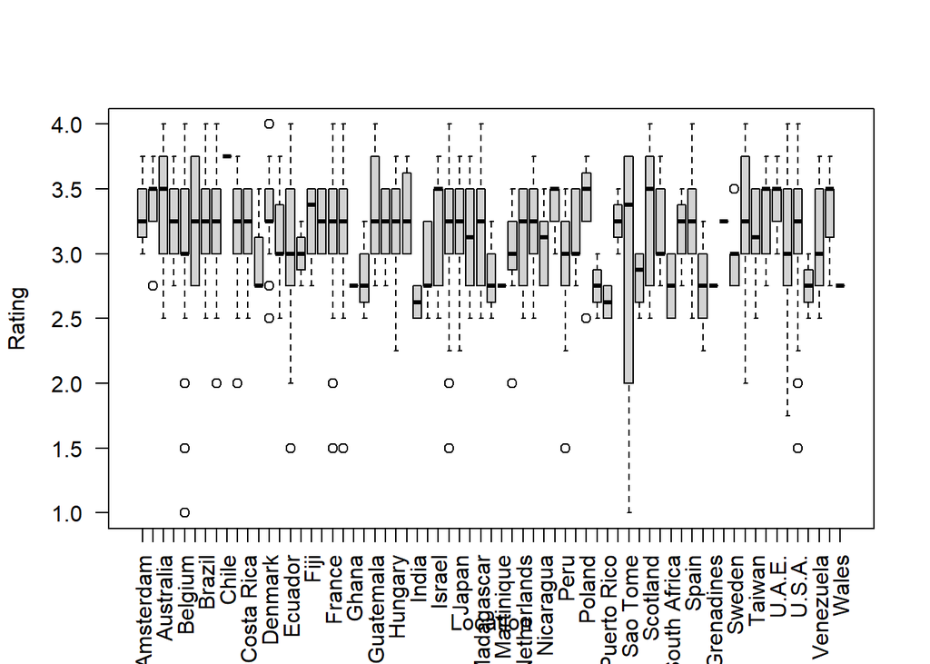

```r
boxplot(Rating ~ Location, data = choco, cex.names=.5, las=2)
```

```r
table(choco$Rating, choco$Bean_Origin)
```

```
##
##        Australia Belize blend Blend Bolivia Bolvia Brazil Burma Cameroon
##   1            0      0     0     3       0      0      0     0        0
##   1.5          0      0     0     5       0      0      0     0        0
##   1.75         0      0     0     0       0      0      1     0        0
##   2            0      0     0    11       1      0      0     0        0
##   2.25         0      0     0     0       0      0      0     0        0
##   2.5          0      1     0     9       7      0      3     0        0
##   2.6          0      0     0     0       0      0      0     0        0
##   2.75         1      9     0    20       9      0      8     0        0
##   3            0     17     1    30      17      0     18     1        2
##   3.25         1     18     0    21      15      1     12     0        1
##   3.5          0     14     0    27      10      0     20     0        0
##   3.75         1      6     0    18       8      0      9     0        0
##   4            0      2     0     7       5      0      4     0        0
##
##        Colombia Congo Costa Rica Cuba Dominican Republic DR Congo Ecuador
##   1           0     0          0    0                  0        0       1
##   1.5         0     0          0    0                  0        0       3
##   1.75        0     0          0    0                  0        0       0
##   2           1     0          1    0                  1        0       6
##   2.25        0     0          0    0                  2        0       0
##   2.5         3     0          3    1                 11        0      22
##   2.6         0     0          0    0                  1        0       0
##   2.75       11     1          5    1                 28        0      24
##   3          16     2         12    2                 46        1      31
##   3.25       13     3          9    2                 42        0      37
##   3.5         9     3          9    3                 39        0      56
##   3.75        8     2          2    3                 36        0      24
##   4           5     0          2    0                  0        0       8
##
##        El Salvador Fiji Gabon Ghana Grenada Guatemala Haiti Honduras India
##   1              0    0     0     0       0         0     0        0     0
##   1.5            0    0     0     1       0         0     0        0     0
##   1.75           0    0     0     0       0         0     0        0     0
##   2              0    0     0     1       0         0     0        0     0
##   2.25           0    0     0     0       1         0     0        0     0
##   2.5            0    2     0     4       3         1     1        1     2
##   2.6            0    0     0     0       0         0     0        0     0
##   2.75           2    3     0     5       5         8     4        5     1
```

[output cut: 80 more lines]

```
##
##        Uganda Vanuatu Venezuela Vietnam
##   1         0       0         0       0
##   1.5       0       0         0       0
##   1.75      0       0         1       0
##   2         0       0         3       0
##   2.25      0       0         3       0
##   2.5       4       1        17       0
##   2.6       0       0         0       0
##   2.75      4       4        29       8
##   3         1       3        59      15
##   3.25      0       1        29      15
##   3.5       1       1        50      21
##   3.75      1       3        36       4
##   4         0       0        18       1
```

A lot of well rated chocolates have bean origins of Venezuala and Vietnam.

**Brainstorm two analyses you would like to perform (with your teammates). Describe in plain language what comparisons are you making. Create suitable numerical and graphical summaries for your analyses. Describe the results.**

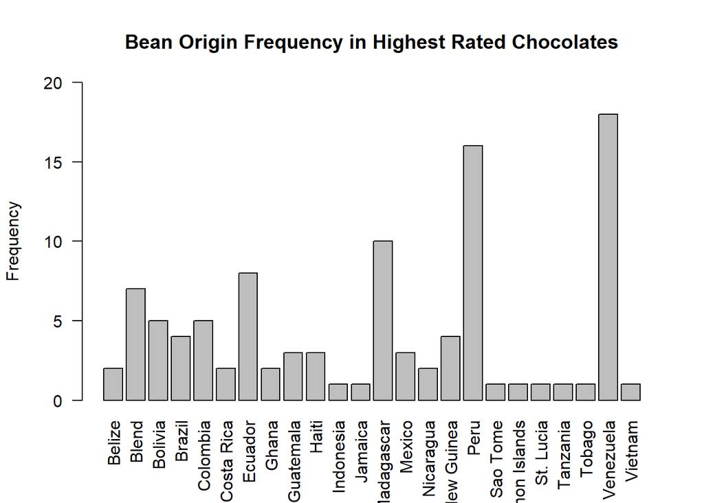

```r
maxRating <- choco[choco$Rating == 4, ]
maxRatingOrigins <- unique(maxRating$Bean_Origin)


barplot(table(maxRating$Bean_Origin),
        ylab = "Frequency",
        ylim = c(0, 20),
        las = 2)
title(main = "Bean Origin Frequency in Highest Rated Chocolates")
```

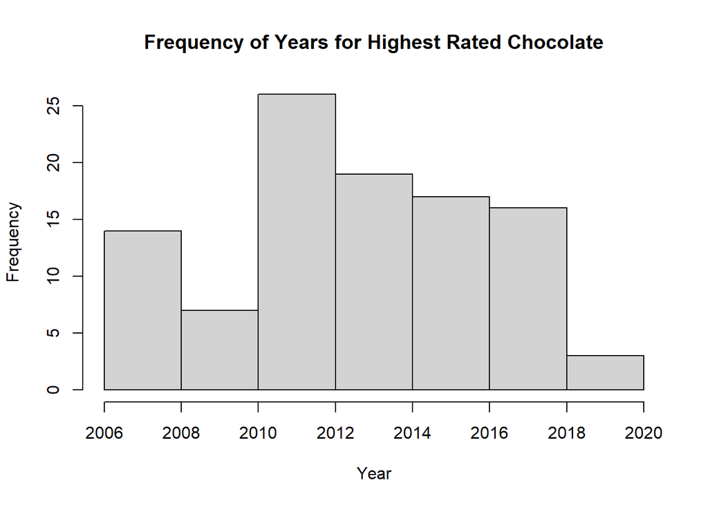

```r
hist(maxRating$Date, xlab='Year', main='Frequency of Years for Highest Rated Chocolate')
```

```r
table(maxRating$Date)
```

```
##
## 2006 2007 2008 2009 2010 2011 2012 2013 2014 2015 2016 2017 2018 2019
##    4    8    2    4    3   15   11   13    6    8    9    5   11    3
```

Most of the highest rated chocolate are from 2011.